# Testing Random Numbers

## Introduction

Suppose we're playing a game based on a coin toss. Naturally, you'll want to know if the coin is fair before playing ("fair" here has the meaning that the: $ probability\ of\ heads\ =\ probability\ of\ tails\ = 1/2 $). How would you test this? Easy: toss the coin a bunch of times (say, 100) and count the number of heads (or tails). If 50 heads show up, you have some confidence that the coin is fair.

But, things being what they are, it's unlikely you would get exactly 50 heads. So what criterion do you use? Is 49 or 51 heads acceptable? Meh, probably. If the number of heads is 10 or 24, then things look suspicious.

We need a way to convert our intuition that the coin is fair (or not) into a systematic test that any palooka can use. If you like probability lingo (and, hey, who doesn't) such a test is called "Binomial" or "Poisson".

Now, what if our game involves throwing a die instead of tossing a coin? Now we have SIX outcomes to test (the set { 1 2 3 4 5 6 }). If the die is "fair" we expect the $probability\ of\ 1\ =\ probability\ of\ 2\ =\ ... =\ probability\ of\ 6\ =\ 1/6$. Suppose we test the die by tossing it 60 times. Suppose we get $[ 10\ 10\ 10\ 10\ 10\ 10\ ]$ (I'm indicating here the number of times each of the six faces turned up). That gives us confidence that the die is fair. But what if we observed $[ 9\ 11\ 10\ 8\ 12\ 10\ ]$? Or some other combination? Again, we need a systematic test that any palooka can use. The tests that handle this kind of issues are frequency test, the most common test is called chi-square (we'll work with it later on the course). You take the data you got $[ 9\ 11\ 10\ 8\ 12\ 10\ ]$ and the data you thought you "should" get $[ 10\ 10\ 10\ 10\ 10\ 10\ ]$ and run it through some formula and it gives you a thumbs up / thumbs down that indicates whether that data is weird or not given your expectation.

Technically chi-square only gives you a yes/no answer, but often people bend the rules and report the "goodness" of the fit, which is really just how 'big" of a thumbs up or a thumbs down you obtained with the formula. The real power of chi-square is that we can test any hypothesis we want. In the die tossing example, there is nothing sacred about $[ 10\ 10\ 10\ 10\ 10\ 10\ ]$ - that's simply the data we expect if the die is "fair". We could just as easily use chi-square to test the hypothesis that the die always comes up 1, or that evens are more likely than odds or that throws sum to a prime number. The only requirement is that we can convert our hypothesis (which is just a bunch of words) into numbers, i.e. the data we expect to observe.

## Frequency Tests and average test

In general we want to proof two things that are neccesary for a set of numbers to be random, **uniformity** and **independence**. We have two ways of dealing with that.

## Problem No.1 Proof of Averages

Demonstrate that the following random numbers pass the criteria of the averages

```python
# This are the imports needed for the current lesson
import pandas as pd
import matplotlib.pyplot as plt
import seaborn as sns

from IPython.display import HTML, display
from math import sqrt
from scipy.stats import chisquare, norm

sns.set(color_codes=True)

data = [[0.145, 0.595, 0.951, 0.57, 0.301],
        [0.505, 0.105, 0.105, 0.635, 0.693],
        [0.364, 0.79, 0.384, 0.244, 0.67],
        [0.76, 0.503, 0.737, 0.705, 0.462],
        [0.333, 0.257, 0.991, 0.635, 0.805],
        [0.482, 0.31, 0.345, 0.99, 0.08]]

display(HTML(
    '<table><tr>{}</tr></table>'.format(
        '</tr><tr>'.join(
            '<td>{}</td>'.format('</td><td>'.join(str(_) for _ in row)) for row in data)
        )
 ))
```

| 0.145 | 0.595 | 0.951 | 0.57 | 0.301 |
| --- | --- | --- | --- | --- |
| 0.505 | 0.105 | 0.105 | 0.635 | 0.693 |
| 0.364 | 0.79 | 0.384 | 0.244 | 0.67 |
| 0.76 | 0.503 | 0.737 | 0.705 | 0.462 |
| 0.333 | 0.257 | 0.991 | 0.635 | 0.805 |
| 0.482 | 0.31 | 0.345 | 0.99 | 0.08 |

```python
numbers = [0.2221, 0.3095, 0.6076, 0.4461, 0.4440,
           0.3846, 0.1520, 0.2909, 0.1734, 0.8916,
           0.4175, 0.5971, 0.7316, 0.9455, 0.4294,
           0.9644, 0.5102, 0.0792, 0.6081, 0.5882,
           0.9625, 0.8672, 0.1823, 0.9053, 0.2870,
           0.5011, 0.7530, 0.6866, 0.7114, 0.1279]
```

Here we can see the distribution of the values for the data

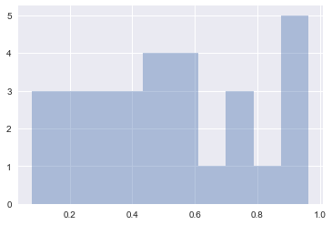

```python
# Here you can see the distribution of the values for the items
ranges = [(i*0.10, (1+i)*0.10) for i in range(0, 10)]

sns.distplot(numbers, bins=10, kde=False, rug=False)
plt.show()
```

```python
# This section here does the process
average = sum(numbers)/len(numbers)
print(average)

# Hyphotesis
mu = 0.5

# alpha = 0.05 = 5%
alpha = 0.05
alpha_divided_by_2 = alpha/2
zetha = norm.ppf(1 - alpha_divided_by_2)
print(zetha)

def lower_limit():
    return mu - zetha / sqrt(12*len(numbers))

def upper_limit():
    return mu + zetha / sqrt(12*len(numbers))

print("lower_limit is: {}".format(lower_limit()))
print("upper_limit is: {}".format(upper_limit()))

if lower_limit() < average < upper_limit():
    print("H0 is accepted")
else:
    print("H1 is accepted")
```

```
0.5259100000000001
1.95996398454
lower_limit is: 0.3967008279492397
upper_limit is: 0.6032991720507602
H0 is accepted
```

# Prueba de media Arimetica

\begin{equation} H_0: \mu =\ 0.5 \\ H_1: \mu \neq\ 0.5\\ \overline{x} = 0.5259 \\ \alpha =\ 0.05 \\ \alpha/2 =\ 0.025\\ Z_{\alpha/2} = 1.9599\ \\ Limite\ Inferior = \mu - \frac{Z_{\alpha/2}}{\sqrt{12n}}\\ Limite\ Superior = \mu + \frac{Z_{\alpha/2}}{\sqrt{12n}}\\ \end{equation}

```python
numbers = [0.34, 0.9, 0.25, 0.89, 0.87, 0.44, 0.12, 0.21, 0.46, 0.67,
           0.83, 0.76, 0.79, 0.64, 0.7, 0.81, 0.94, 0.74, 0.22, 0.74,
           0.96, 0.99, 0.77, 0.67, 0.56, 0.41, 0.52, 0.73, 0.99, 0.02,
           0.47, 0.3, 0.17, 0.82, 0.56, 0.05, 0.45, 0.31, 0.78, 0.05,
           0.79, 0.71, 0.23, 0.19, 0.82, 0.93, 0.65, 0.37, 0.39, 0.42,
           0.99, 0.17, 0.99, 0.46, 0.05, 0.66, 0.1, 0.42, 0.18, 0.49,
           0.37, 0.51, 0.54, 0.01, 0.81, 0.28, 0.69, 0.34, 0.75, 0.49,
           0.72, 0.43, 0.56, 0.97, 0.3, 0.94, 0.96, 0.58, 0.73, 0.05,
           0.06, 0.39, 0.84, 0.24, 0.4, 0.64, 0.4, 0.19, 0.79, 0.62,
           0.18, 0.26, 0.97, 0.88, 0.64, 0.47, 0.6, 0.11, 0.29, 0.78]
```

Here we can see the distribution of the values for the data

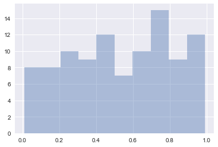

```python
# Display the structure of the data of the second element
sns.set(color_codes=True)

ranges = [(i*0.10, (1+i)*0.10) for i in range(0, 10)]

sns.distplot(numbers, bins=10, kde=False, rug=False)
plt.show()
```

# Chi-Square Test

La prueba Chi-Cuadrada en lugar de medir la diferencia de cada punto entre la muestra y la desviación verdadera, checa la desviación del valor esperado

\begin{equation} \tilde{\chi}^2=\sum_{i=1}^{n} \frac{(O_i - E_i)^2}{E_i} \\ E_i\ =\ \frac{N}{n} \end{equation}

```python
from scipy.stats import chi2

values = []
for i in range(10):
    numbers_within_range = []
    for n in numbers:
        if i*.1 <= n <= (i+1)*.1:
            numbers_within_range.append(n)
    values.append(numbers_within_range)

# The count of all the numbers in ranges from 0-0.1, 0.1-0.2 ... to 0.9-1.0
observed_values = [len(l) for l in values]

# The expected values, if the distribution is well distributed, we would expect the same amount
# of numbers for each section [10, 10, ..., 10]
expected_values = [10 for x in range(10)]

chi_square_observed = sum([(observed - 10)**2/10 for observed in observed_values])

# Get The theoritical value

chi_squared_stat = chi2.ppf(q=0.95, df = 99)
print(chi_square_observed)
print(chi_squared_stat)
```

```
4.6000000000000005
123.225221453
```

## Notes

- A pretty good [z-table](http://www.statisticshowto.com/tables/z-table/)